# Adult_Salary_Predict (P1)

### Violin_heu visualization (categorical variables)

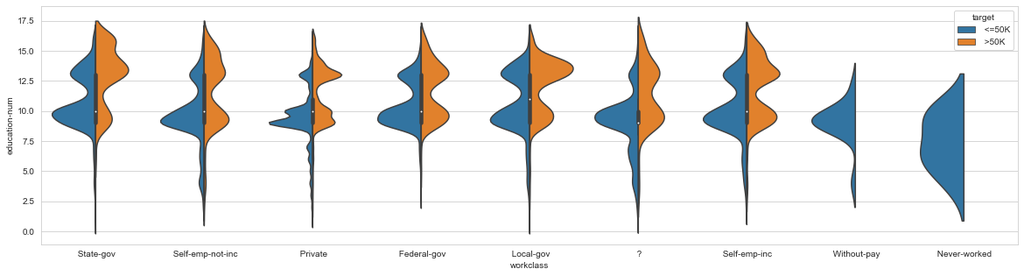

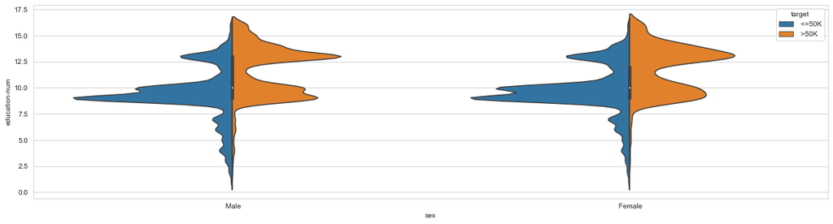

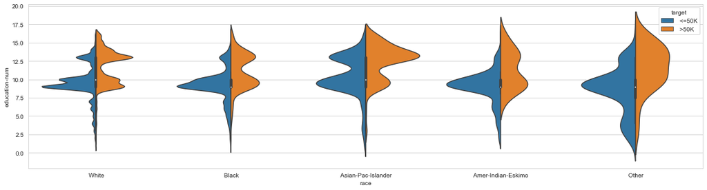

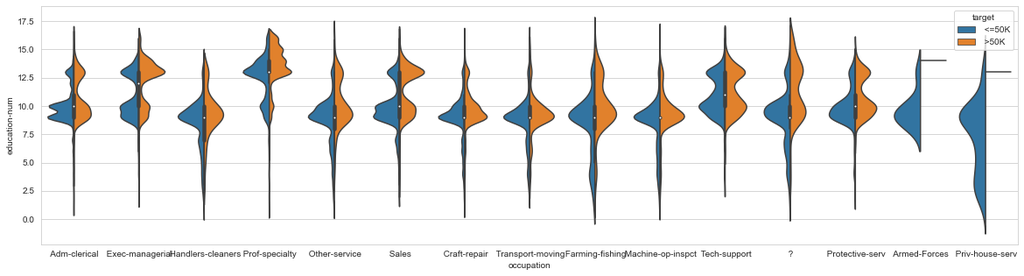

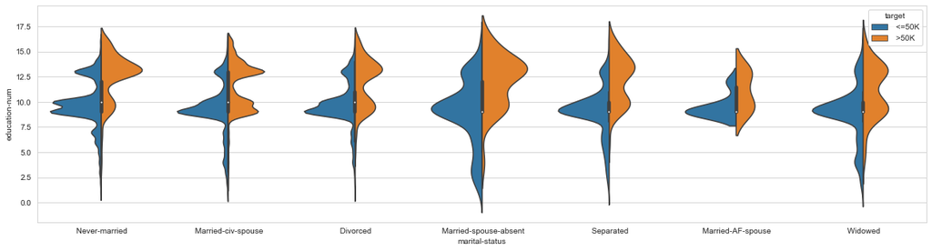

```python
cat_cols = [ 'workclass', 'sex', 'race','occupation','marital-status']
def plot_violin_hue(df, cols, col_y = 'education-num', hue_col = 'target'):
    for col in cols:
        plt.figure(figsize=(20,5))
        sns.set_style("whitegrid")
        sns.violinplot(col, col_y, data=df, hue = hue_col, split = True)
        plt.xlabel(col) # Set text for the x axis
        plt.ylabel(col_y)# Set text for y axis
        plt.show()

plot_violin_hue(df, cat_cols)
```

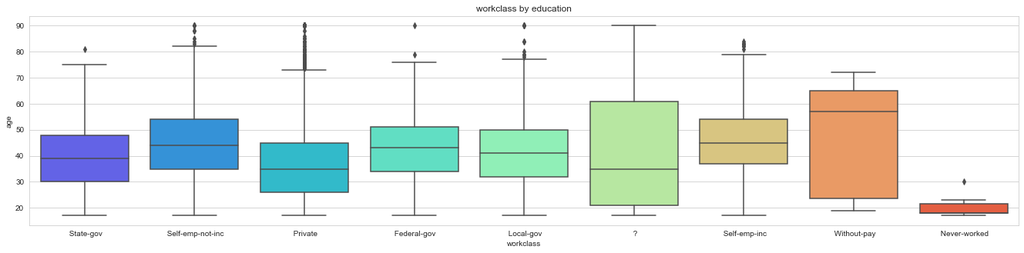

```python
plt.figure(figsize=(23,5))
sns.boxplot(x='workclass',y='age',data=df, palette='rainbow')
plt.title("workclass by education")
```

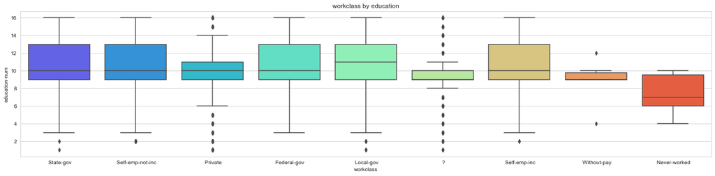

```python
plt.figure(figsize=(23,5))
sns.boxplot(x='workclass',y='education-num',data=df, palette='rainbow')
plt.title("workclass by education")
```

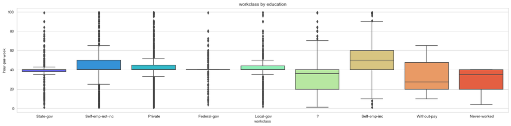

```python
plt.figure(figsize=(23,5))
sns.boxplot(x='workclass',y='hour-per-week',data=df, palette='rainbow')
plt.title("workclass by education")
```

in above I have compared workclass with all numerical variables in order to observe its subcategorical behaviors and I noted an intresting similarity behaviors betwean our missing values among without pay.  
if you compare all three plots together you find similar compassions and expansions in just these two.  
as a matter of fact if we are considering of replcaing our missing values with respect of this notation we can think of withoutpay as an option.

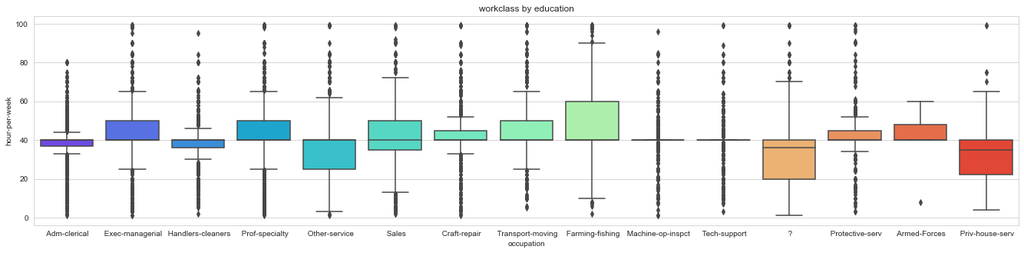

```python
plt.figure(figsize=(23,5))
sns.boxplot(x='occupation',y='hour-per-week',data=df, palette='rainbow')
plt.title("workclass by education")
```

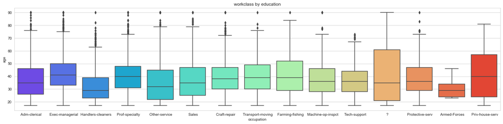

```python
plt.figure(figsize=(23,5))
sns.boxplot(x='occupation',y='age',data=df, palette='rainbow')
plt.title("workclass by education")
```

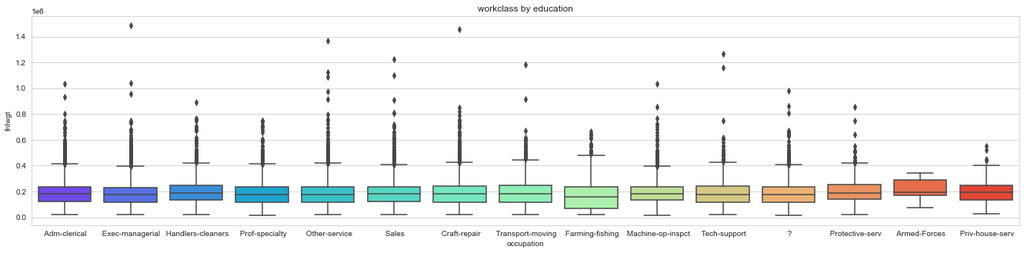

```python
plt.figure(figsize=(23,5))
sns.boxplot(x='occupation',y='fnlwgt',data=df, palette='rainbow')
plt.title("workclass by education")
```

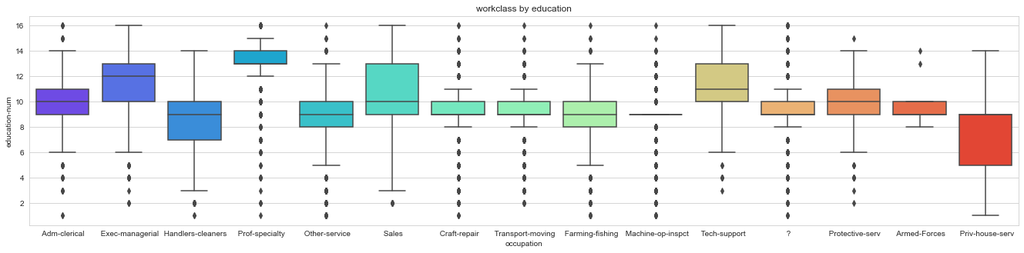

```python
plt.figure(figsize=(23,5))
sns.boxplot(x='occupation',y='education-num',data=df, palette='rainbow')
plt.title("workclass by education")
```

in this project which is part 1, we consider of replcaing our missing values with the most closes attributes.

```python
df['workclass']=df['workclass'].replace(' ?', ' Without-pay')
df['occupation']=df['occupation'].replace(" ?",' Priv-house-serv')



#df['column name'] = df['column name'].replace(['old value'],'new value')
```

### Feature engineering

- I have made some new variables from categorical variabels based on the intrest of increasing our classifier impacts. I made that decision from some sort of other plots that i have not added here because it would have looked very longer than it is and would be looks more reapeting with our next plots.  
  since they are added among our original attributes you can see if we have a good detection for our target.

```python
relationship_categories = {' Unmarried':'group1',' Own-child':'group1',
                    ' Other-relative':'group1',' Not-in-family':'group1',
                    ' Wife':'group2',' Husband':'group3'}
df['relationship_new'] = [relationship_categories[x] for x in df['relationship']]
```

```python
bins = [0,40,100]
labels = ['0-40','41+']
df['hour-per-week-cat'] = pd.cut(df['hour-per-week'], bins, labels = labels,include_lowest = True)
```

```python
bins = [0,900,3000,5000,8000, 10000]
labels = ['0-900','1000-3000','3100-5000','6000-8000', '9000-10000']

df['capital-gain1'] = pd.cut(df['capitl-gain'], bins, labels = labels,include_lowest = True)
```

```python
df['workclass'].unique()
```

```
array([' State-gov', ' Self-emp-not-inc', ' Private', ' Federal-gov',
       ' Local-gov', ' Without-pay', ' Self-emp-inc', ' Never-worked'],
      dtype=object)
```

```python
workclass_categories = {' State-gov':'the_rest', ' Self-emp-not-inc':'the_rest',
                    ' Private':'the_rest', ' Federal-gov':'the_rest',
                    ' Local-gov':'the_rest', 'Private':'the_rest',' Self-emp-inc':'the_rest',' Without-pay':'Withoutpay-neverworked',' Never-worked':'Withoutpay-neverworked'}
df['workclass_new'] = [workclass_categories[x] for x in df['workclass']]
df['workclass_new'].value_counts()
```

```
the_rest                  30704
Withoutpay-neverworked     1857
Name: workclass_new, dtype: int64
```

```python
df['education'].unique()
```

```
array([' Bachelors', ' HS-grad', ' 11th', ' Masters', ' 9th',
       ' Some-college', ' Assoc-acdm', ' Assoc-voc', ' 7th-8th',
       ' Doctorate', ' Prof-school', ' 5th-6th', ' 10th', ' 1st-4th',
       ' Preschool', ' 12th'], dtype=object)
```

```python
education_categories = {' Bachelors':'bourgeois', ' HS-grad':'nodiff',
                    ' 11th':'lower-class',' Masters':'bourgeois',
                    ' 9th':'lower-class',' Some-college':'nodiff',' Assoc-acdm':'nodiff', ' 7th-8th':'lower-class',' Doctorate':'bourgeois',' Assoc-voc':'nodiff',
                    ' Prof-school':'bourgeois',' 5th-6th':'lower-class',' 10th':'lower-class', ' 10th':'lower-class',' 1st-4th':'lower-class',' Preschool':'bourgeois',' 12th':'lower-class' }
df['education_new'] = [education_categories[x] for x in df['education']]
df['education_new'].value_counts()
```

```
nodiff         20241
bourgeois       8118
lower-class     4202
Name: education_new, dtype: int64
```

```python
df['relationship'].unique()
```

```
array([' Not-in-family', ' Husband', ' Wife', ' Own-child', ' Unmarried',
       ' Other-relative'], dtype=object)
```

```python
occupation_categories = {' Adm-clerical':'B', ' Exec-managerial':'A',
                   ' Handlers-cleaners':'B', ' Prof-specialty':'A',
                    ' Other-service':'B', ' Sales':'B',' Craft-repair':'B',' Transport-moving':'B',' Farming-fishing':'B',' Machine-op-inspct':'B',' Tech-support':'N',' Priv-house-serv':'B',' Protective-serv':'N',' Armed-Forces':'N'}
df['occupation_new'] = [occupation_categories[x] for x in df['occupation']]
df['occupation_new'].value_counts()
```

```
B    22769
A     8206
N     1586
Name: occupation_new, dtype: int64
```

```python
relationship_categories = {' Unmarried':'group1',' Own-child':'group1',
                    ' Other-relative':'group1',' Not-in-family':'group1',
                    ' Wife':'group2',' Husband':'group3'}
df['relationship_new'] = [relationship_categories[x] for x in df['relationship']]
df['relationship_new'].value_counts()
```

```
group1    17800
group3    13193
group2     1568
Name: relationship_new, dtype: int64
```

### Frequenty plot

```
workclass
```

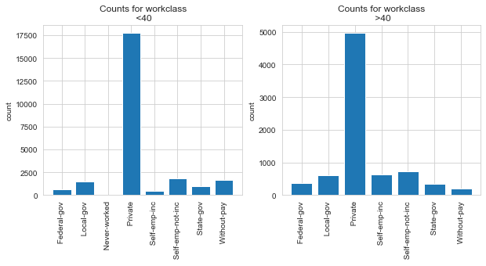

```
education
```

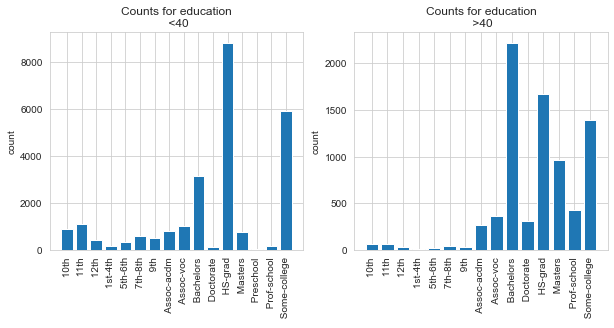

```
marital-status
```

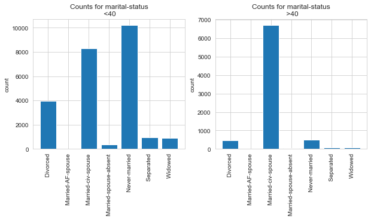

```
occupation
```

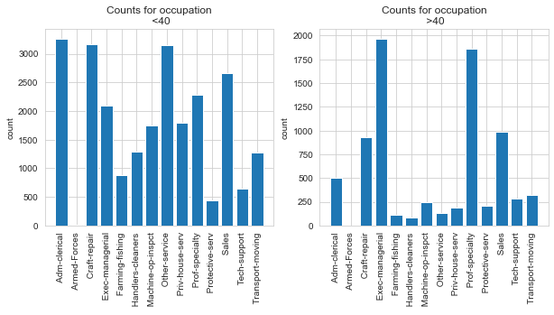

```
occupation_new
```

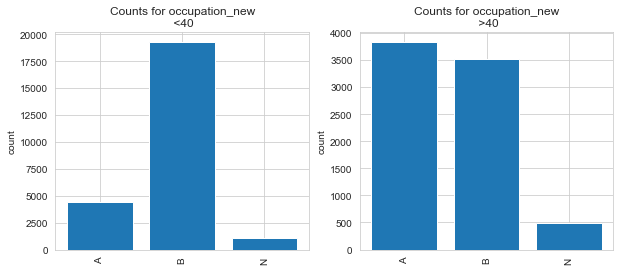

```
workclass_new
```

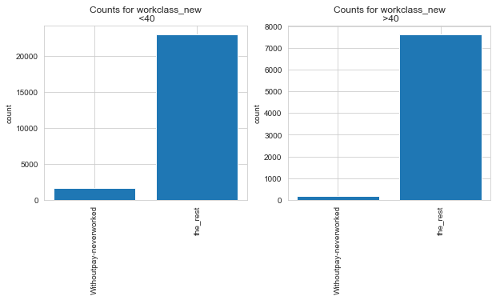

```
relationship_new
```

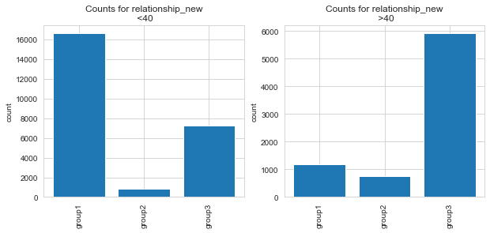

```
relationship
```

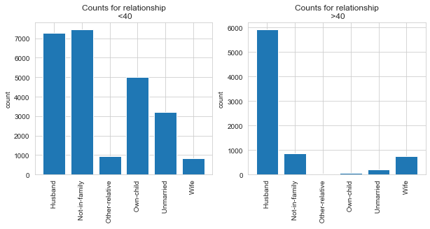

```
race
```

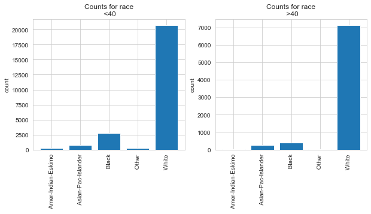

```
sex
```

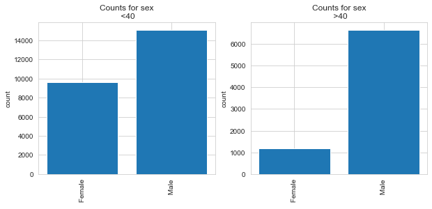

```
hour-per-week-cat
```

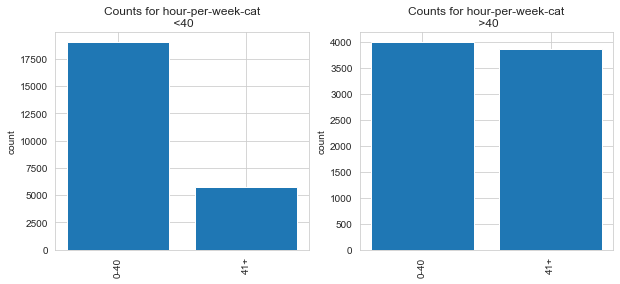

```
capital-gain1
```

[figure not shown]

```
education_new
```

[1 more figures not shown]

```python
import numpy as np
cat_cols = ['workclass', 'education', 'marital-status', 'occupation','occupation_new','workclass_new','relationship_new',
                  'relationship', 'race', 'sex','hour-per-week-cat','capital-gain1'
                  ,'education_new']

df['dummy'] = np.ones(shape = df.shape[0])
for col in cat_cols:
    print(col)
    counts = df[['dummy', 'target_encoded', col]].groupby(['target_encoded', col], as_index = False).count()
    temp = counts[counts['target_encoded'] == 0][[col, 'dummy']]
    _ = plt.figure(figsize = (10,4))
    plt.subplot(1, 2, 1)
    temp = counts[counts['target_encoded'] == 0][[col, 'dummy']]
    plt.bar(temp[col], temp.dummy)
    plt.xticks(rotation=90)
    plt.title('Counts for ' + col + '\n <40')
    plt.ylabel('count')
    plt.subplot(1, 2, 2)
    temp = counts[counts['target_encoded'] == 1][[col, 'dummy']]
    plt.bar(temp[col], temp.dummy)
    plt.xticks(rotation=90)
    plt.title('Counts for ' + col + '\n >40')
    plt.ylabel('count')
    plt.show()
```

- on education_new we see signifcant difference on lower-class and bourgeois.
- on capital-gain1 we see proof of our theory that all of the third quartile contained in target datas >40, which is good news but might not be enough to let us to use it in our feauture selection, but we defenietley can consider thinkig twice about this when we get there.
- hour-per-week shows huge disturbution of >40 on our righ bin,
- for the rest I will let you to take a look and see which has significants changes and which has not.

### Pearson Correlation

this is another great method that lead us for the final decision making on our feature selection, as you see we have all type of attributes.

```python
df.apply(lambda x : pd.factorize(x)[0]).corr(method='pearson', min_periods=1)
```

|  | age | workclass | fnlwgt | education | education-num | marital-status | occupation | relationship | race | sex | ... | native-country | target | hour-per-week-cat | capital-gain1 | dummy | target_encoded | workclass_new | education_new | occupation_new | relationship_new |
| --- | --- | --- | --- | --- | --- | --- | --- | --- | --- | --- | --- | --- | --- | --- | --- | --- | --- | --- | --- | --- | --- |
| age | 1.000000 | 0.070622 | 0.076682 | 0.044320 | 0.044320 | 0.097691 | 0.060351 | -0.020508 | -0.013882 | 0.013328 | ... | -0.010688 | -0.044498 | -0.024542 | -0.022443 | NaN | -0.044498 | 0.126818 | 0.077777 | -0.037368 | -0.012304 |
| workclass | 0.070622 | 1.000000 | 0.012385 | 0.011691 | 0.011691 | 0.036071 | 0.220310 | 0.015061 | 0.009376 | 0.019380 | ... | -0.010180 | 0.047834 | 0.015820 | -0.017036 | NaN | 0.047834 | 0.543012 | -0.009221 | -0.007348 | 0.022888 |
| fnlwgt | 0.076682 | 0.012385 | 1.000000 | 0.034911 | 0.034911 | 0.037005 | 0.014966 | 0.037741 | 0.036233 | 0.090497 | ... | -0.010298 | -0.058700 | -0.029176 | -0.001760 | NaN | -0.058700 | 0.035391 | 0.056925 | -0.026798 | -0.032906 |
| education | 0.044320 | 0.011691 | 0.034911 | 1.000000 | 1.000000 | 0.008507 | 0.073672 | 0.044319 | 0.029638 | 0.000550 | ... | 0.067619 | -0.046218 | -0.019965 | -0.007840 | NaN | -0.046218 | 0.052373 | 0.459383 | -0.047074 | -0.026174 |
| education-num | 0.044320 | 0.011691 | 0.034911 | 1.000000 | 1.000000 | 0.008507 | 0.073672 | 0.044319 | 0.029638 | 0.000550 | ... | 0.067619 | -0.046218 | -0.019965 | -0.007840 | NaN | -0.046218 | 0.052373 | 0.459383 | -0.047074 | -0.026174 |
| marital-status | 0.097691 | 0.036071 | 0.037005 | 0.008507 | 0.008507 | 1.000000 | 0.004335 | 0.029083 | 0.012722 | 0.181870 | ... | 0.001912 | 0.002644 | -0.014366 | -0.013848 | NaN | 0.002644 | 0.030735 | 0.049883 | -0.005136 | -0.051550 |
| occupation | 0.060351 | 0.220310 | 0.014966 | 0.073672 | 0.073672 | 0.004335 | 1.000000 | -0.018008 | 0.016088 | -0.154540 | ... | 0.016096 | -0.103447 | -0.028767 | -0.003748 | NaN | -0.103447 | 0.462312 | 0.230576 | -0.033456 | 0.022551 |
| relationship | -0.020508 | 0.015061 | 0.037741 | 0.044319 | 0.044319 | 0.029083 | -0.018008 | 1.000000 | 0.096808 | 0.273414 | ... | 0.042444 | -0.171294 | -0.131709 | 0.014294 | NaN | -0.171294 | 0.052310 | 0.158109 | -0.109382 | -0.207705 |
| race | -0.013882 | 0.009376 | 0.036233 | 0.029638 | 0.029638 | 0.012722 | 0.016088 | 0.096808 | 1.000000 | 0.067840 | ... | 0.241650 | -0.067713 | -0.085004 | 0.008894 | NaN | -0.067713 | 0.021805 | 0.034669 | -0.027025 | -0.059002 |
| sex | 0.013328 | 0.019380 | 0.090497 | 0.000550 | 0.000550 | 0.181870 | -0.154540 | 0.273414 | 0.067840 | 1.000000 | ... | 0.005977 | -0.215980 | -0.165213 | 0.033800 | NaN | -0.215980 | 0.065222 | 0.027202 | -0.027694 | -0.251628 |
| capitl-gain | 0.056664 | 0.025144 | 0.019787 | 0.005438 | 0.005438 | 0.050772 | -0.005435 | -0.012549 | -0.010851 | -0.011339 | ... | 0.002388 | 0.091250 | 0.035786 | -0.516999 | NaN | 0.091250 | 0.009660 | -0.043282 | 0.035923 | 0.023286 |
| capital-loss | 0.017703 | 0.010418 | 0.011433 | 0.005792 | 0.005792 | 0.022601 | -0.009501 | -0.015410 | -0.007996 | -0.001277 | ... | 0.002527 | 0.038593 | 0.018519 | 0.027966 | NaN | 0.038593 | 0.001044 | -0.027634 | 0.022400 | 0.007449 |
| hour-per-week | 0.080641 | 0.030037 | 0.026265 | 0.046631 | 0.046631 | 0.028753 | 0.038421 | 0.025558 | -0.020509 | 0.055507 | ... | -0.007930 | -0.026776 | 0.331790 | -0.004559 | NaN | -0.026776 | 0.078309 | 0.032411 | -0.014003 | -0.025468 |
| native-country | -0.010688 | -0.010180 | -0.010298 | 0.067619 | 0.067619 | 0.001912 | 0.016096 | 0.042444 | 0.241650 | 0.005977 | ... | 1.000000 | -0.028478 | -0.042523 | 0.001576 | NaN | -0.028478 | -0.004465 | 0.033066 | -0.020116 | 0.003397 |
| target | -0.044498 | 0.047834 | -0.058700 | -0.046218 | -0.046218 | 0.002644 | -0.103447 | -0.171294 | -0.067713 | -0.215980 | ... | -0.028478 | 1.000000 | 0.206932 | -0.070114 | NaN | 1.000000 | -0.079348 | -0.324104 | 0.261799 | 0.424244 |
| hour-per-week-cat | -0.024542 | 0.015820 | -0.029176 | -0.019965 | -0.019965 | -0.014366 | -0.028767 | -0.131709 | -0.085004 | -0.165213 | ... | -0.042523 | 0.206932 | 1.000000 | -0.018852 | NaN | 0.206932 | -0.048338 | -0.148984 | 0.100864 | 0.109478 |
| capital-gain1 | -0.022443 | -0.017036 | -0.001760 | -0.007840 | -0.007840 | -0.013848 | -0.003748 | 0.014294 | 0.008894 | 0.033800 | ... | 0.001576 | -0.070114 | -0.018852 | 1.000000 | NaN | -0.070114 | -0.000646 | 0.023462 | -0.017033 | -0.072192 |
| dummy | NaN | NaN | NaN | NaN | NaN | NaN | NaN | NaN | NaN | NaN | ... | NaN | NaN | NaN | NaN | NaN | NaN | NaN | NaN | NaN | NaN |
| target_encoded | -0.044498 | 0.047834 | -0.058700 | -0.046218 | -0.046218 | 0.002644 | -0.103447 | -0.171294 | -0.067713 | -0.215980 | ... | -0.028478 | 1.000000 | 0.206932 | -0.070114 | NaN | 1.000000 | -0.079348 | -0.324104 | 0.261799 | 0.424244 |
| workclass_new | 0.126818 | 0.543012 | 0.035391 | 0.052373 | 0.052373 | 0.030735 | 0.462312 | 0.052310 | 0.021805 | 0.065222 | ... | -0.004465 | -0.079348 | -0.048338 | -0.000646 | NaN | -0.079348 | 1.000000 | 0.086131 | -0.150801 | -0.037417 |
| education_new | 0.077777 | -0.009221 | 0.056925 | 0.459383 | 0.459383 | 0.049883 | 0.230576 | 0.158109 | 0.034669 | 0.027202 | ... | 0.033066 | -0.324104 | -0.148984 | 0.023462 | NaN | -0.324104 | 0.086131 | 1.000000 | -0.378580 | -0.103656 |
| occupation_new | -0.037368 | -0.007348 | -0.026798 | -0.047074 | -0.047074 | -0.005136 | -0.033456 | -0.109382 | -0.027025 | -0.027694 | ... | -0.020116 | 0.261799 | 0.100864 | -0.017033 | NaN | 0.261799 | -0.150801 | -0.378580 | 1.000000 | 0.096255 |
| relationship_new | -0.012304 | 0.022888 | -0.032906 | -0.026174 | -0.026174 | -0.051550 | 0.022551 | -0.207705 | -0.059002 | -0.251628 | ... | 0.003397 | 0.424244 | 0.109478 | -0.072192 | NaN | 0.424244 | -0.037417 | -0.103656 | 0.096255 | 1.000000 |

23 rows × 23 columns

after all I did to revive capital-gain we see our enginnered one with capital gain1 still has very low correlation level with our target. but we hour-per-week,edcuation-new,occupation-new and relationship-new show great bond with our target. also I like you to check their correlation with their own origin class which describe that some of them doesnt have very much similiarity and its very intresting.

```python
df.apply(lambda x : pd.factorize(x)[0]).corr(method='pearson', min_periods=1)
```

|  | age | workclass | fnlwgt | education | education-num | marital-status | occupation | relationship | race | sex | ... | native-country | target | hour-per-week-cat | capital-gain1 | dummy | target_encoded | workclass_new | education_new | occupation_new | relationship_new |
| --- | --- | --- | --- | --- | --- | --- | --- | --- | --- | --- | --- | --- | --- | --- | --- | --- | --- | --- | --- | --- | --- |
| age | 1.000000 | 0.070622 | 0.076682 | 0.044320 | 0.044320 | 0.097691 | 0.060351 | -0.020508 | -0.013882 | 0.013328 | ... | -0.010688 | -0.044498 | -0.074349 | -0.022443 | NaN | -0.044498 | 0.126818 | 0.077777 | -0.037368 | -0.012304 |
| workclass | 0.070622 | 1.000000 | 0.012385 | 0.011691 | 0.011691 | 0.036071 | 0.220310 | 0.015061 | 0.009376 | 0.019380 | ... | -0.010180 | 0.047834 | 0.001404 | -0.017036 | NaN | 0.047834 | 0.543012 | -0.009221 | -0.007348 | 0.022888 |
| fnlwgt | 0.076682 | 0.012385 | 1.000000 | 0.034911 | 0.034911 | 0.037005 | 0.014966 | 0.037741 | 0.036233 | 0.090497 | ... | -0.010298 | -0.058700 | -0.043715 | -0.001760 | NaN | -0.058700 | 0.035391 | 0.056925 | -0.026798 | -0.032906 |
| education | 0.044320 | 0.011691 | 0.034911 | 1.000000 | 1.000000 | 0.008507 | 0.073672 | 0.044319 | 0.029638 | 0.000550 | ... | 0.067619 | -0.046218 | -0.038576 | -0.007840 | NaN | -0.046218 | 0.052373 | 0.459383 | -0.047074 | -0.026174 |
| education-num | 0.044320 | 0.011691 | 0.034911 | 1.000000 | 1.000000 | 0.008507 | 0.073672 | 0.044319 | 0.029638 | 0.000550 | ... | 0.067619 | -0.046218 | -0.038576 | -0.007840 | NaN | -0.046218 | 0.052373 | 0.459383 | -0.047074 | -0.026174 |
| marital-status | 0.097691 | 0.036071 | 0.037005 | 0.008507 | 0.008507 | 1.000000 | 0.004335 | 0.029083 | 0.012722 | 0.181870 | ... | 0.001912 | 0.002644 | -0.010486 | -0.013848 | NaN | 0.002644 | 0.030735 | 0.049883 | -0.005136 | -0.051550 |
| occupation | 0.060351 | 0.220310 | 0.014966 | 0.073672 | 0.073672 | 0.004335 | 1.000000 | -0.018008 | 0.016088 | -0.154540 | ... | 0.016096 | -0.103447 | -0.043407 | -0.003748 | NaN | -0.103447 | 0.462312 | 0.230576 | -0.033456 | 0.022551 |
| relationship | -0.020508 | 0.015061 | 0.037741 | 0.044319 | 0.044319 | 0.029083 | -0.018008 | 1.000000 | 0.096808 | 0.273414 | ... | 0.042444 | -0.171294 | -0.169478 | 0.014294 | NaN | -0.171294 | 0.052310 | 0.158109 | -0.109382 | -0.207705 |
| race | -0.013882 | 0.009376 | 0.036233 | 0.029638 | 0.029638 | 0.012722 | 0.016088 | 0.096808 | 1.000000 | 0.067840 | ... | 0.241650 | -0.067713 | -0.082309 | 0.008894 | NaN | -0.067713 | 0.021805 | 0.034669 | -0.027025 | -0.059002 |
| sex | 0.013328 | 0.019380 | 0.090497 | 0.000550 | 0.000550 | 0.181870 | -0.154540 | 0.273414 | 0.067840 | 1.000000 | ... | 0.005977 | -0.215980 | -0.204451 | 0.033800 | NaN | -0.215980 | 0.065222 | 0.027202 | -0.027694 | -0.251628 |
| capitl-gain | 0.056664 | 0.025144 | 0.019787 | 0.005438 | 0.005438 | 0.050772 | -0.005435 | -0.012549 | -0.010851 | -0.011339 | ... | 0.002388 | 0.091250 | 0.034988 | -0.516999 | NaN | 0.091250 | 0.009660 | -0.043282 | 0.035923 | 0.023286 |
| capital-loss | 0.017703 | 0.010418 | 0.011433 | 0.005792 | 0.005792 | 0.022601 | -0.009501 | -0.015410 | -0.007996 | -0.001277 | ... | 0.002527 | 0.038593 | 0.018016 | 0.027966 | NaN | 0.038593 | 0.001044 | -0.027634 | 0.022400 | 0.007449 |
| hour-per-week | 0.080641 | 0.030037 | 0.026265 | 0.046631 | 0.046631 | 0.028753 | 0.038421 | 0.025558 | -0.020509 | 0.055507 | ... | -0.007930 | -0.026776 | 0.228436 | -0.004559 | NaN | -0.026776 | 0.078309 | 0.032411 | -0.014003 | -0.025468 |
| native-country | -0.010688 | -0.010180 | -0.010298 | 0.067619 | 0.067619 | 0.001912 | 0.016096 | 0.042444 | 0.241650 | 0.005977 | ... | 1.000000 | -0.028478 | -0.037529 | 0.001576 | NaN | -0.028478 | -0.004465 | 0.033066 | -0.020116 | 0.003397 |
| target | -0.044498 | 0.047834 | -0.058700 | -0.046218 | -0.046218 | 0.002644 | -0.103447 | -0.171294 | -0.067713 | -0.215980 | ... | -0.028478 | 1.000000 | 0.244120 | -0.070114 | NaN | 1.000000 | -0.079348 | -0.324104 | 0.261799 | 0.424244 |
| hour-per-week-cat | -0.074349 | 0.001404 | -0.043715 | -0.038576 | -0.038576 | -0.010486 | -0.043407 | -0.169478 | -0.082309 | -0.204451 | ... | -0.037529 | 0.244120 | 1.000000 | -0.021339 | NaN | 0.244120 | -0.097477 | -0.179390 | 0.121580 | 0.138941 |
| capital-gain1 | -0.022443 | -0.017036 | -0.001760 | -0.007840 | -0.007840 | -0.013848 | -0.003748 | 0.014294 | 0.008894 | 0.033800 | ... | 0.001576 | -0.070114 | -0.021339 | 1.000000 | NaN | -0.070114 | -0.000646 | 0.023462 | -0.017033 | -0.072192 |
| dummy | NaN | NaN | NaN | NaN | NaN | NaN | NaN | NaN | NaN | NaN | ... | NaN | NaN | NaN | NaN | NaN | NaN | NaN | NaN | NaN | NaN |
| target_encoded | -0.044498 | 0.047834 | -0.058700 | -0.046218 | -0.046218 | 0.002644 | -0.103447 | -0.171294 | -0.067713 | -0.215980 | ... | -0.028478 | 1.000000 | 0.244120 | -0.070114 | NaN | 1.000000 | -0.079348 | -0.324104 | 0.261799 | 0.424244 |
| workclass_new | 0.126818 | 0.543012 | 0.035391 | 0.052373 | 0.052373 | 0.030735 | 0.462312 | 0.052310 | 0.021805 | 0.065222 | ... | -0.004465 | -0.079348 | -0.097477 | -0.000646 | NaN | -0.079348 | 1.000000 | 0.086131 | -0.150801 | -0.037417 |
| education_new | 0.077777 | -0.009221 | 0.056925 | 0.459383 | 0.459383 | 0.049883 | 0.230576 | 0.158109 | 0.034669 | 0.027202 | ... | 0.033066 | -0.324104 | -0.179390 | 0.023462 | NaN | -0.324104 | 0.086131 | 1.000000 | -0.378580 | -0.103656 |
| occupation_new | -0.037368 | -0.007348 | -0.026798 | -0.047074 | -0.047074 | -0.005136 | -0.033456 | -0.109382 | -0.027025 | -0.027694 | ... | -0.020116 | 0.261799 | 0.121580 | -0.017033 | NaN | 0.261799 | -0.150801 | -0.378580 | 1.000000 | 0.096255 |
| relationship_new | -0.012304 | 0.022888 | -0.032906 | -0.026174 | -0.026174 | -0.051550 | 0.022551 | -0.207705 | -0.059002 | -0.251628 | ... | 0.003397 | 0.424244 | 0.138941 | -0.072192 | NaN | 0.424244 | -0.037417 | -0.103656 | 0.096255 | 1.000000 |

23 rows × 23 columns

### encoding categorical and feature selection

```python
def encode_string(cat_features):
    ## First encode the strings to numeric categories
    enc = preprocessing.LabelEncoder()
    enc.fit(cat_features)
    enc_cat_features = enc.transform(cat_features)
    ## Now, apply one hot encoding
    ohe = preprocessing.OneHotEncoder()
    encoded = ohe.fit(enc_cat_features.reshape(-1,1))
    return encoded.transform(enc_cat_features.reshape(-1,1)).toarray()

categorical_columns = ['education_new','relationship_new','sex','hour-per-week-cat']

Features = encode_string(df['relationship'])
for col in categorical_columns:
    temp = encode_string(df[col])
    Features = np.concatenate([Features, temp], axis = 1)

print(Features.shape)
print(Features[:2, :])
```

```
(32561, 16)
[[0. 1. 0. 0. 0. 0. 1. 0. 0. 1. 0. 0. 0. 1. 1. 0.]
 [1. 0. 0. 0. 0. 0. 1. 0. 0. 0. 0. 1. 0. 1. 1. 0.]]
```

a quick note about my feature selection, as you see I have chosed education_new but not education. and its because it has great correlation with target but its also not the same as education-num,I have initiated education_new from education but by the fact they are not the same.  
now we should already know education-num is the same as education and if we added both they would cancel eachother out and thats not the result we want.

### Feature concatenation with our numerical variables

```python
Features = np.concatenate([Features, np.array(df[['age', 'education-num', 'hour-per-week'
                            ]])], axis = 1)
print(Features.shape)
print(Features[:2, :])
```

```
(32561, 19)
[[ 0.  1.  0.  0.  0.  0.  1.  0.  0.  1.  0.  0.  0.  1.  1.  0. 39. 13.
  40.]
 [ 1.  0.  0.  0.  0.  0.  1.  0.  0.  0.  0.  1.  0.  1.  1.  0. 50. 13.
  13.]]
```

### Feautre Sampling

```python
labels = np.array(df['target_encoded'])
## Randomly sample cases to create independent training and test data
nr.seed(9988)
indx = range(Features.shape[0])
indx = ms.train_test_split(indx, test_size = 8140)
X_train = Features[indx[0],:]
y_train = np.ravel(labels[indx[0]])
X_test = Features[indx[1],:]
y_test = np.ravel(labels[indx[1]])
```

Im using bernouli sampling method to decrease biased effects on my selection, inorder to do that we usally pick 25 percent of our whole dataset size

```python
print(X_train.shape)
print(X_test.shape)
```

```
(24421, 19)
(8140, 19)
```

now lets make sure our training and our testing matrix dimensions make sense. as you see above we have 24421 by 19 for our train set and 8140 by 19 for our test set which is completly what we need for here.

```python
print(X_train[:5,16:])
```

```
[[33.  9. 55.]
 [59.  9. 40.]
 [26.  7. 20.]
 [37. 10. 30.]
 [27.  9. 40.]]
```

before we go for the ML proccesing we need to find our datas with highest varience and scale them. because we dont want age variable as instance bias our selection. and we see they are located from column 16 to the end

### Scaling

```python
scaler = preprocessing.StandardScaler().fit(X_train[:,16:])
X_train[:,16:] = scaler.transform(X_train[:,16:])
X_test[:,16:] = scaler.transform(X_test[:,16:])
X_train[:2,:]
```

```
array([[ 0.        ,  1.        ,  0.        ,  0.        ,  0.        ,
         0.        ,  0.        ,  0.        ,  1.        ,  1.        ,
         0.        ,  0.        ,  0.        ,  1.        ,  0.        ,
         1.        , -0.40702024, -0.41670567,  1.1752837 ],
       [ 0.        ,  1.        ,  0.        ,  0.        ,  0.        ,
         0.        ,  0.        ,  0.        ,  1.        ,  1.        ,
         0.        ,  0.        ,  0.        ,  1.        ,  1.        ,
         0.        ,  1.49743053, -0.41670567, -0.03607131]])
```

### Random Forest ML Model

I have chosed Random forest, its because it has high acuurancy and compare to decision tree it wont effected by having heavy selection.

```python
#Import Random Forest Model
from sklearn.ensemble import RandomForestClassifier

#Create a Gaussian Classifier
clf=RandomForestClassifier(n_estimators=100)

#Train the model using the training sets y_pred=clf.predict(X_test)
clf.fit(X_train,y_train)
```

```
RandomForestClassifier()
```

```python
probabilities = clf.predict_proba(X_test)
```

```python
def score_model(probs, threshold):
    return np.array([1 if x > threshold else 0 for x in probs[:,1]])
scores = score_model(probabilities, 0.5)
print(np.array(scores[:15]))
print(y_test[:15])
```

```
[0 0 1 0 0 0 1 0 0 0 0 0 1 0 0]
[0 0 1 0 0 0 1 0 0 0 0 0 0 0 1]
```

```python
def print_metrics(labels, scores):
    metrics = sklm.precision_recall_fscore_support(labels, scores)
    conf = sklm.confusion_matrix(labels, scores)
    print('                 Confusion matrix')
    print('                 Score positive    Score negative')
    print('Actual positive    %6d' % conf[0,0] + '             %5d' % conf[0,1])
    print('Actual negative    %6d' % conf[1,0] + '             %5d' % conf[1,1])
    print('')
    print('Accuracy  %0.2f' % sklm.accuracy_score(labels, scores))
    print(' ')
    print('           Positive      Negative')
    print('Num case   %6d' % metrics[3][0] + '        %6d' % metrics[3][1])
    print('Precision  %6.2f' % metrics[0][0] + '        %6.2f' % metrics[0][1])
    print('Recall     %6.2f' % metrics[1][0] + '        %6.2f' % metrics[1][1])
    print('F1         %6.2f' % metrics[2][0] + '        %6.2f' % metrics[2][1])



print_metrics(y_test, scores)
```

```
                 Confusion matrix
                 Score positive    Score negative
Actual positive      5449               712
Actual negative       918              1061

Accuracy  0.80

           Positive      Negative
Num case     6161          1979
Precision    0.86          0.60
Recall       0.88          0.54
F1           0.87          0.57
```

I have my confusion matrix,  
My actual positive selection compares to negative-positive ones look promissing but on my negative cases as you see Actual negative copare to scored positive ones are not good!

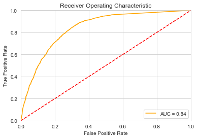

```python
def plot_auc(labels, probs):
    ## Compute the false positive rate, true positive rate
    ## and threshold along with the AUC
    fpr, tpr, threshold = sklm.roc_curve(labels, probs[:,1])
    auc = sklm.auc(fpr, tpr)

    ## Plot the result
    plt.title('Receiver Operating Characteristic')
    plt.plot(fpr, tpr, color = 'orange', label = 'AUC = %0.2f' % auc)
    plt.legend(loc = 'lower right')
    plt.plot([0, 1], [0, 1],'r--')
    plt.xlim([0, 1])
    plt.ylim([0, 1])
    plt.ylabel('True Positive Rate')
    plt.xlabel('False Positive Rate')
    plt.show()

plot_auc(y_test, probabilities)
```

on my ROC plot we see a beautiful yellow curve with 84 percent, but it doesnt change the fact that I have lack of power in detecting negative cases and it need to be improved!

### PCA

```python
pca_mod = skde.PCA()
pca_comps = pca_mod.fit(X_train)
pca_comps
```

```
PCA()
```

```python
print(pca_comps.explained_variance_ratio_)
print(np.sum(pca_comps.explained_variance_ratio_))
```

```
[2.87579039e-01 1.99872239e-01 1.76040849e-01 1.19387833e-01
 5.88363254e-02 5.02826900e-02 3.25644548e-02 2.83184833e-02
 1.96627058e-02 1.62042064e-02 6.39032311e-03 4.86085096e-03
 1.21793609e-28 1.54716510e-29 5.56325267e-30 3.33403182e-30
 2.42259001e-32 1.73096428e-33 2.31417406e-34]
0.9999999999999999
```

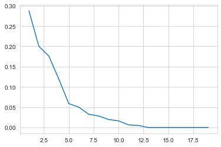

```python
def plot_explained(mod):
    comps = mod.explained_variance_ratio_
    x = range(len(comps))
    x = [y + 1 for y in x]
    plt.plot(x,comps)

plot_explained(pca_comps)
```

this pca plot shows the changes of impaction with increasing components,  
for every presentation I usually like to start evaluating with just 2 component because its more undrestanding for my audience but we see we have a change in slope around 2. so it wouldnt be so far from what we actually should see. remember the fact when we use PCA its really important that we can find the most improvments with the least count of components. because PCA is here to reduce its noise and as it name shows its the technique that removes dependency or redundancy in the data. so lets keep it minimal as possiple.

### Running PCA with 2 components

```python
pca_mod_5 = skde.PCA(n_components = 2)
pca_mod_5.fit(X_train)
Comps = pca_mod_5.transform(X_train)
Comps.shape
```

```
(24421, 2)
```

```python
## Define and fit the logistic regression model
log_mod_5 = RandomForestClassifier(n_estimators=100)
log_mod_5.fit(Comps, y_train)
```

```
RandomForestClassifier()
```

```python
def score_model(probs, threshold):
    return np.array([1 if x > threshold else 0 for x in probs[:,1]])

def print_metrics(labels, probs, threshold):
    scores = score_model(probs, threshold)
    metrics = sklm.precision_recall_fscore_support(labels, scores)
    conf = sklm.confusion_matrix(labels, scores)
    print('                 Confusion matrix')
    print('                 Score positive    Score negative')
    print('Actual positive    %6d' % conf[0,0] + '             %5d' % conf[0,1])
    print('Actual negative    %6d' % conf[1,0] + '             %5d' % conf[1,1])
    print('')
    print('Accuracy        %0.2f' % sklm.accuracy_score(labels, scores))
    print('AUC             %0.2f' % sklm.roc_auc_score(labels, probs[:,1]))
    print('Macro precision %0.2f' % float((float(metrics[0][0]) + float(metrics[0][1]))/2.0))
    print('Macro recall    %0.2f' % float((float(metrics[1][0]) + float(metrics[1][1]))/2.0))
    print(' ')
    print('           Positive      Negative')
    print('Num case   %6d' % metrics[3][0] + '        %6d' % metrics[3][1])
    print('Precision  %6.2f' % metrics[0][0] + '        %6.2f' % metrics[0][1])
    print('Recall     %6.2f' % metrics[1][0] + '        %6.2f' % metrics[1][1])
    print('F1         %6.2f' % metrics[2][0] + '        %6.2f' % metrics[2][1])

def plot_auc(labels, probs):
    ## Compute the false positive rate, true positive rate
    ## and threshold along with the AUC
    fpr, tpr, threshold = sklm.roc_curve(labels, probs[:,1])
    auc = sklm.auc(fpr, tpr)

    ## Plot the result
    plt.title('Receiver Operating Characteristic')
    plt.plot(fpr, tpr, color = 'orange', label = 'AUC = %0.2f' % auc)
    plt.legend(loc = 'lower right')
    plt.plot([0, 1], [0, 1],'r--')
    plt.xlim([0, 1])
    plt.ylim([0, 1])
    plt.ylabel('True Positive Rate')
    plt.xlabel('False Positive Rate')
    plt.show()

probabilities = log_mod_5.predict_proba(pca_mod_5.transform(X_test))
print_metrics(y_test, probabilities, 0.3)
plot_auc(y_test, probabilities)
```

[output not shown]

```python
def score_model(probs, threshold):
    return np.array([1 if x > threshold else 0 for x in probs[:,1]])
scores = score_model(probabilities, 0.5)
print(np.array(scores[:15]))
print(y_test[:15])
```

```
[0 0 0 1 0 0 0 1 0 0 0 1 0 1 0]
[0 0 1 0 0 0 1 0 0 0 0 0 0 0 1]
```

```python
def print_metrics(labels, scores):
    metrics = sklm.precision_recall_fscore_support(labels, scores)
    conf = sklm.confusion_matrix(labels, scores)
    print('                 Confusion matrix')
    print('                 Score positive    Score negative')
    print('Actual positive    %6d' % conf[0,0] + '             %5d' % conf[0,1])
    print('Actual negative    %6d' % conf[1,0] + '             %5d' % conf[1,1])
    print('')
    print('Accuracy  %0.2f' % sklm.accuracy_score(labels, scores))
    print(' ')
    print('           Positive      Negative')
    print('Num case   %6d' % metrics[3][0] + '        %6d' % metrics[3][1])
    print('Precision  %6.2f' % metrics[0][0] + '        %6.2f' % metrics[0][1])
    print('Recall     %6.2f' % metrics[1][0] + '        %6.2f' % metrics[1][1])
    print('F1         %6.2f' % metrics[2][0] + '        %6.2f' % metrics[2][1])



print_metrics(y_test, scores)
```

[output not shown]

now lets check our result again

### Running PCA with 4 components

I know 5 could be the next number of components but I like to check it lower and compare the diffrence as we prone to have it at light as possible.

```python
pca_mod_5 = skde.PCA(n_components = 4)
pca_mod_5.fit(X_train)
Comps = pca_mod_5.transform(X_train)
```

```python
Comps.shape
```

```
(24421, 4)
```

```python
# Define and fit the logistic regression model
log_mod_5 = RandomForestClassifier(n_estimators=100)
log_mod_5.fit(Comps, y_train)
```

```
RandomForestClassifier()
```

```
                 Confusion matrix
                 Score positive    Score negative
Actual positive      4803              1358
Actual negative       527              1452

Accuracy        0.77
AUC             0.84
Macro precision 0.71
Macro recall    0.76

           Positive      Negative
Num case     6161          1979
Precision    0.90          0.52
Recall       0.78          0.73
F1           0.84          0.61
```

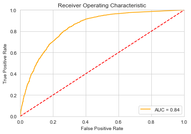

```python
def score_model(probs, threshold):
    return np.array([1 if x > threshold else 0 for x in probs[:,1]])

def print_metrics(labels, probs, threshold):
    scores = score_model(probs, threshold)
    metrics = sklm.precision_recall_fscore_support(labels, scores)
    conf = sklm.confusion_matrix(labels, scores)
    print('                 Confusion matrix')
    print('                 Score positive    Score negative')
    print('Actual positive    %6d' % conf[0,0] + '             %5d' % conf[0,1])
    print('Actual negative    %6d' % conf[1,0] + '             %5d' % conf[1,1])
    print('')
    print('Accuracy        %0.2f' % sklm.accuracy_score(labels, scores))
    print('AUC             %0.2f' % sklm.roc_auc_score(labels, probs[:,1]))
    print('Macro precision %0.2f' % float((float(metrics[0][0]) + float(metrics[0][1]))/2.0))
    print('Macro recall    %0.2f' % float((float(metrics[1][0]) + float(metrics[1][1]))/2.0))
    print(' ')
    print('           Positive      Negative')
    print('Num case   %6d' % metrics[3][0] + '        %6d' % metrics[3][1])
    print('Precision  %6.2f' % metrics[0][0] + '        %6.2f' % metrics[0][1])
    print('Recall     %6.2f' % metrics[1][0] + '        %6.2f' % metrics[1][1])
    print('F1         %6.2f' % metrics[2][0] + '        %6.2f' % metrics[2][1])

def plot_auc(labels, probs):
    ## Compute the false positive rate, true positive rate
    ## and threshold along with the AUC
    fpr, tpr, threshold = sklm.roc_curve(labels, probs[:,1])
    auc = sklm.auc(fpr, tpr)

    ## Plot the result
    plt.title('Receiver Operating Characteristic')
    plt.plot(fpr, tpr, color = 'orange', label = 'AUC = %0.2f' % auc)
    plt.legend(loc = 'lower right')
    plt.plot([0, 1], [0, 1],'r--')
    plt.xlim([0, 1])
    plt.ylim([0, 1])
    plt.ylabel('True Positive Rate')
    plt.xlabel('False Positive Rate')
    plt.show()

probabilities = log_mod_5.predict_proba(pca_mod_5.transform(X_test))
print_metrics(y_test, probabilities, 0.3)
plot_auc(y_test, probabilities)
```

on above I see that Im getting better result, but my accuracy has droped 3 percent and I have lost a few of my correct selected score for positive cases. please also check Macro percision as well as recall, I will go ahead and try more components in respect with the PCA plot that I have before I start my improve performane stage.

```python
pca_mod_5 = skde.PCA(n_components = 5)
pca_mod_5.fit(X_train)
Comps = pca_mod_5.transform(X_train)
```

```python
Comps.shape
```

```
(24421, 5)
```

```python
 #Define and fit the logistic regression model
log_mod_5 = RandomForestClassifier(n_estimators=100)
log_mod_5.fit(Comps, y_train)
```

```
RandomForestClassifier()
```

```
                 Confusion matrix
                 Score positive    Score negative
Actual positive      4818              1343
Actual negative       523              1456

Accuracy        0.77
AUC             0.84
Macro precision 0.71
Macro recall    0.76

           Positive      Negative
Num case     6161          1979
Precision    0.90          0.52
Recall       0.78          0.74
F1           0.84          0.61
```

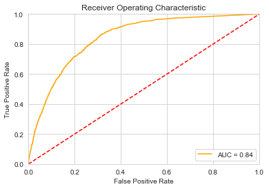

```python
probabilities = log_mod_5.predict_proba(pca_mod_5.transform(X_test))
print_metrics(y_test, probabilities, 0.3)
plot_auc(y_test, probabilities)
```

```python
pca_mod_10 = skde.PCA(n_components = 10)
pca_mod_10.fit(X_train)
Comps_10 = pca_mod_10.transform(X_train)
Comps_10.shape
```

```
(24421, 10)
```

```python
## define and fit the linear regression model
log_mod_10 = RandomForestClassifier(n_estimators=100)
log_mod_10.fit(Comps_10, y_train)
```

```
RandomForestClassifier()
```

```
                 Confusion matrix
                 Score positive    Score negative
Actual positive      4831              1330
Actual negative       525              1454

Accuracy        0.77
AUC             0.84
Macro precision 0.71
Macro recall    0.76

           Positive      Negative
Num case     6161          1979
Precision    0.90          0.52
Recall       0.78          0.73
F1           0.84          0.61
```

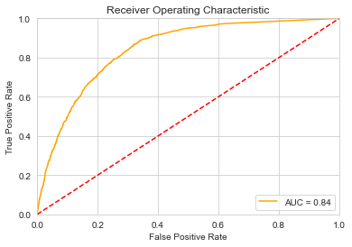

```python
probabilities = log_mod_10.predict_proba(pca_mod_10.transform(X_test))
print_metrics(y_test, probabilities, 0.3)
plot_auc(y_test, probabilities)
```

```python
def print_format(f,x,y,z):
    print('Fold %2d    %4.3f        %4.3f      %4.3f' % (f, x, y, z))

def print_cv(scores):
    fold = [x + 1 for x in range(len(scores['test_precision_macro']))]
    print('         Precision     Recall       AUC')
    [print_format(f,x,y,z) for f,x,y,z in zip(fold, scores['test_precision_macro'],
                                          scores['test_recall_macro'],
                                          scores['test_roc_auc'])]
    print('-' * 40)
    print('Mean       %4.3f        %4.3f      %4.3f' %
          (np.mean(scores['test_precision_macro']), np.mean(scores['test_recall_macro']), np.mean(scores['test_roc_auc'])))
    print('Std        %4.3f        %4.3f      %4.3f' %
          (np.std(scores['test_precision_macro']), np.std(scores['test_recall_macro']), np.std(scores['test_roc_auc'])))

Labels = labels.reshape(labels.shape[0],)
scoring = ['precision_macro', 'recall_macro', 'roc_auc']
```

here I have cross validation and its drain on us like cold water because it shows how bad it could go in some cases like fold 2.

```python
pca_mod = skde.PCA(n_components = 10)
pca_mod.fit(Features)
Comps = pca_mod.transform(Features)

scores = ms.cross_validate(log_mod_10, Comps, Labels, scoring=scoring,
                        cv=10, return_train_score=False)
print_cv(scores)
```

```
         Precision     Recall       AUC
Fold  1    0.734        0.717      0.845
Fold  2    0.718        0.694      0.842
Fold  3    0.760        0.733      0.852
Fold  4    0.735        0.702      0.839
Fold  5    0.737        0.724      0.844
Fold  6    0.738        0.721      0.850
Fold  7    0.750        0.721      0.852
Fold  8    0.757        0.731      0.855
Fold  9    0.749        0.713      0.849
Fold 10    0.743        0.721      0.839
----------------------------------------
Mean       0.742        0.718      0.847
Std        0.012        0.011      0.005
```

on next I will perform my model with differnet approach which I wont replace my missing value and I try no feature engineering and will hold it as simple as possible and we can check comparison betwean these two, thanks!